# Health Outcomes and Interventions

Amwaj Almalki

## Idea primary aim

Health outcome measures can be used to measure health policies of various countries. Governments have the ability to enact polices that will improve health outcomes.This app will provide a way to measure the association between these policies and improvement in health outcomes.

The world data bank (WDB) contains information on health outcomes as well as other country level properties that can be influence by health policy. For my project, I will find the relevant data series on the WDB and present this data to the user. The user will be able to explore these data series to find relations between policy actions and health outcome improvement. This interface will be coded in RShiny. With this app policy makers will be able to make data driven decisions.

### Analysis Idea

Health Services Research. The goal is to identify the health outcome measure such as mortality or life expectancy. Next, measures of government intervention in society have to be identified. The app will let the user measure the association of these interventions and outcomes. One intervention could be education. These will be compared across countries to look for association. In addition, moderators or confounders such as age demographics will be used to adjust. The user will be able to choose from data series that I will pre-select. There well be options for graphs and statistical analysis.

## Code Sample and Proof-of Concept

One simple analysis is shown below. The user would be able to choose out of many.

### Sample

1. Choose data
   1. Pick a good outcome (Health outcome). A measure of health care quality
   2. Make sure the data set has good predictors of health.
   3. Identify the intervention.
   4. Identify moderators.
   5. Identify mediators.
   6. Identify confounders.
   7. Need a good mix is continuous and categorical and dichotomous for the user to choose.
2. Analyze the data
   1. ggplot (grammar of graphics)
   2. gtsummary (grammar of tables)

### Data Source

Will use the World Data Bank. Note that there is an app called `WDI`.

Data can also be Downloaded from (https://databank.worldbank.org/source/education-statistics-%5e-all-indicators#)

But it is easier to use the app.

Two example series were downloaded:

- Mortality rate under 5 per 1000
- Percent of students enrolled in Health and Welfare programs in tertiary education who are female

There is a search engine.

```r
r <- WDI::WDIsearch("mortality")
r %>% as_tibble() %>% head
```

```
## # A tibble: 6 x 2
##   indicator         name
##   <chr>             <chr>
## 1 5.51.01.03.mortal Child mortality
## 2 HF.DYN.IMRT.IN    Mortality rate, infant (per 1,000 live births)
## 3 HF.DYN.IMRT.IN.Q1 Mortality rate, infant (per 1,000 live births): Q1 (lowest)
## 4 HF.DYN.IMRT.IN.Q2 Mortality rate, infant (per 1,000 live births): Q2
## 5 HF.DYN.IMRT.IN.Q3 Mortality rate, infant (per 1,000 live births): Q3
## 6 HF.DYN.IMRT.IN.Q4 Mortality rate, infant (per 1,000 live births): Q4
```

Extract the data from WDI for the same indicators. This can be done as the user makes selections.

```r
#h <- WDI::WDI(indicator = c("UIS.FEP.56.F900",'SH.DYN.MORT'))
```

store the data in the package if needed.

```r
#usethis::use_data(h,overwrite = TRUE)
```

```r
h %>%
  na.omit() %>%
  head
```

```
##     iso2c country year UIS.FEP.56.F900 SH.DYN.MORT
## 603    AD Andorra 2002        87.09677         6.9
## 604    AD Andorra 2003        86.36364         6.6
## 605    AD Andorra 2004        87.80488         6.3
## 606    AD Andorra 2005        83.01887         6.0
## 607    AD Andorra 2006        77.77778         5.7
## 609    AD Andorra 2008        75.00000         5.1
```

Various summary options will be available. The user must be able to explore the data.

```r
h %>% count(country) %>%
  arrange(-n) %>%
  head
```

```
##          country  n
## 1    Afghanistan 61
## 2        Albania 61
## 3        Algeria 61
## 4 American Samoa 61
## 5        Andorra 61
## 6         Angola 61
```

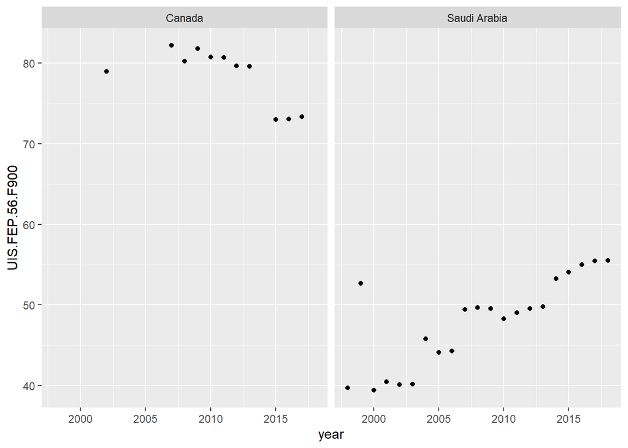

```r
h %>%
  na.omit() %>%
  filter(country %in% c('Canada','Saudi Arabia')) %>%
  ggplot(aes(x=year, y = UIS.FEP.56.F900))+
  geom_point() +
  facet_wrap(~country)
```

In addition to plots, The user will be able to create summary tables.

```r
h %>%
  filter(country %in% c('Canada','Saudi Arabia')) %>%
  select(country,UIS.FEP.56.F900,SH.DYN.MORT) %>%
  janitor::clean_names() %>%
gtsummary::tbl_summary(h, by = 'country')
```

| **Characteristic** | **Canada**, N = 61<sup>1</sup> | **Saudi Arabia**, N = 61<sup>1</sup> |
| --- | --- | --- |
| Percentage of students enrolled in Health and Welfare programmes in tertiary education who are female (%) | 80 (76, 81) | 49 (44, 53) |
| Unknown | 50 | 40 |
| Mortality rate, under-5 (per 1,000 live births) | 8 (6, 17) | 29 (14, 72) |
| Unknown | 1 | 13 |

<sup>*1*</sup> Statistics presented: median (IQR)

## Challenges

1. The first challenge is to learn about data set so that I can provide the user with 10 to 20 useful data series. These can be downloaded in real time.
2. I may need to supplement the data with other websites.
3. How to program RShiny.
4. Other challenges is creating the maps of the countries and using those in graphics.
5. Picking the right analysis choices to offer the user.
6. Find a way to publish the app.

## To-do

1. Find data series. (OCT 18)
2. Load the data at the user request (RShiny Hello World). (OCT 31)
3. Develop data exploration template for RShiny. (NOV 7)
4. Data modeling template.(NOV 14)
5. Summarize the model. (NOV 20)